# HT3.2_LR_JMG

Jorge Mario García

6/23/2024

# Explorando la Regresión Lineal con el Conjunto de Datos Auto MPG: Una Experiencia Personal

La regresión lineal es una técnica fundamental en el análisis de datos que permite comprender y predecir relaciones entre variables. En este artículo, compartiré mi experiencia al trabajar con el conjunto de datos “Auto MPG”, un clásico en la comunidad de ciencia de datos que contiene información sobre el consumo de combustible de diferentes automóviles, junto con características como el peso, la aceleración y la potencia. Mi objetivo principal fue explorar cómo estas variables afectan el consumo de combustible (medido en millas por galón, o MPG) y optimizar un modelo de regresión lineal para hacer predicciones precisas.

## Metodología: Pasos en el Análisis de Datos

### Carga y Exploración Inicial de los Datos

El primer paso fue cargar el conjunto de datos “Auto MPG” en R y realizar una inspección inicial para comprender su estructura. Revisé las primeras filas del data frame y verifiqué la presencia de valores NA (ausentes). Este proceso de limpieza es crucial para asegurar que los análisis posteriores sean precisos.

```r
# Carga y exploración de datos
library(dplyr)
# Importa los datos en R
df <- read.csv("auto-mpg.csv.xls", stringsAsFactors = FALSE)

# Mostrar las primeras filas
head(df)
```

```
##   mpg cylinders displacement horsepower weight acceleration model.year origin
## 1  18         8          307        130   3504         12.0         70      1
## 2  15         8          350        165   3693         11.5         70      1
## 3  18         8          318        150   3436         11.0         70      1
## 4  16         8          304        150   3433         12.0         70      1
## 5  17         8          302        140   3449         10.5         70      1
## 6  15         8          429        198   4341         10.0         70      1
##                    car.name
## 1 chevrolet chevelle malibu
## 2         buick skylark 320
## 3        plymouth satellite
## 4             amc rebel sst
## 5               ford torino
## 6          ford galaxie 500
```

```r
# Examinando la estructura de los datos
str(df)
```

```
## 'data.frame':    398 obs. of  9 variables:
##  $ mpg         : num  18 15 18 16 17 15 14 14 14 15 ...
##  $ cylinders   : int  8 8 8 8 8 8 8 8 8 8 ...
##  $ displacement: num  307 350 318 304 302 429 454 440 455 390 ...
##  $ horsepower  : chr  "130" "165" "150" "150" ...
##  $ weight      : int  3504 3693 3436 3433 3449 4341 4354 4312 4425 3850 ...
##  $ acceleration: num  12 11.5 11 12 10.5 10 9 8.5 10 8.5 ...
##  $ model.year  : int  70 70 70 70 70 70 70 70 70 70 ...
##  $ origin      : int  1 1 1 1 1 1 1 1 1 1 ...
##  $ car.name    : chr  "chevrolet chevelle malibu" "buick skylark 320" "plymouth satellite" "amc rebel sst" ...
```

```r
# Verificar si hay valores NA
sum(is.na(df))
```

```
## [1] 0
```

```r
# Limpiar los datos (remover filas con NA)
df <- df %>% na.omit()

# Verificar de nuevo si hay valores NA
sum(is.na(df))
```

```
## [1] 0
```

```r
# Convertir columnas a numeric si es necesario
df$horsepower <- as.numeric(df$horsepower)
df <- df %>% na.omit()

# Calcular estadísticas descriptivas de las variables mpg, weight y horsepower
summary(df %>% select(mpg, weight, horsepower))
```

```
##       mpg            weight       horsepower
##  Min.   : 9.00   Min.   :1613   Min.   : 46.0
##  1st Qu.:17.00   1st Qu.:2225   1st Qu.: 75.0
##  Median :22.75   Median :2804   Median : 93.5
##  Mean   :23.45   Mean   :2978   Mean   :104.5
##  3rd Qu.:29.00   3rd Qu.:3615   3rd Qu.:126.0
##  Max.   :46.60   Max.   :5140   Max.   :230.0
```

### Ajuste de Modelos y Análisis de Resultados

Con los datos limpios, el siguiente paso fue ajustar un modelo de regresión lineal simple usando el peso del automóvil como predictor del consumo de combustible. Esta etapa incluyó el ajuste del modelo, la visualización de los resultados y el diagnóstico de problemas comunes como la no linealidad y la heterocedasticidad.

```r
# Regresión Lineal Simple
modelo <- lm(mpg ~ weight, data = df)
resumen_modelo <- summary(modelo)

# Imprimir resumen del modelo
print(resumen_modelo)
```

```
##
## Call:
## lm(formula = mpg ~ weight, data = df)
##
## Residuals:
##      Min       1Q   Median       3Q      Max
## -11.9736  -2.7556  -0.3358   2.1379  16.5194
##
## Coefficients:
##              Estimate Std. Error t value Pr(>|t|)
## (Intercept) 46.216524   0.798673   57.87   <2e-16 ***
## weight      -0.007647   0.000258  -29.64   <2e-16 ***
## ---
## Signif. codes:  0 '***' 0.001 '**' 0.01 '*' 0.05 '.' 0.1 ' ' 1
##
## Residual standard error: 4.333 on 390 degrees of freedom
## Multiple R-squared:  0.6926, Adjusted R-squared:  0.6918
## F-statistic: 878.8 on 1 and 390 DF,  p-value: < 2.2e-16
```

```r
# Extraer y imprimir el R cuadrado
r_squared <- resumen_modelo$r.squared
r_squared_ajustado <- resumen_modelo$adj.r.squared

cat("R cuadrado: ", r_squared, "\n")
```

```
## R cuadrado:  0.6926304
```

```r
cat("R cuadrado ajustado: ", r_squared_ajustado, "\n")
```

```
## R cuadrado ajustado:  0.6918423
```

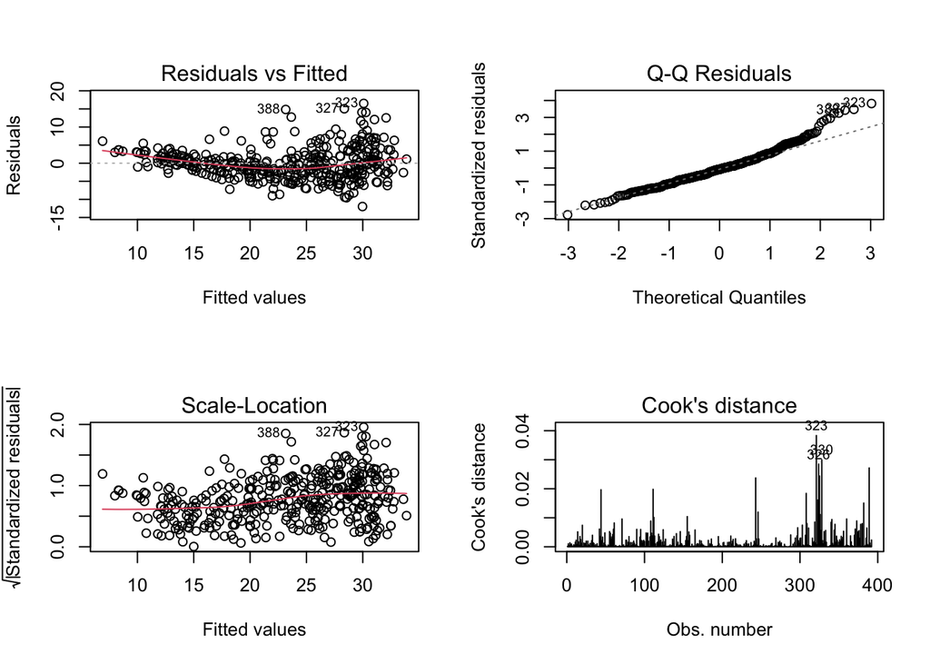

```r
# Diagnóstico del modelo: gráficos de residuos
par(mfrow=c(2,2))
plot(modelo, which = 1:4)
```

```r
par(mfrow=c(1,1))
```

### Transformación de Variables y Diagnóstico de Problemas

Durante el análisis, noté problemas de no linealidad y heterocedasticidad. Para abordar esto, transformé las variables mediante logaritmos y volví a ajustar el modelo. Esta transformación a menudo ayuda a estabilizar la varianza y a linearizar relaciones no lineales.

```r
# Transformación logarítmica
df <- df %>%
  mutate(log_mpg = log(mpg),
         log_weight = log(weight))

# Ajustar el modelo con las variables transformadas
modelo_log <- lm(log_mpg ~ log_weight, data = df)

# Resumir el modelo transformado
summary(modelo_log)
```

```
##
## Call:
## lm(formula = log_mpg ~ log_weight, data = df)
##
## Residuals:
##      Min       1Q   Median       3Q      Max
## -0.52321 -0.10446 -0.00772  0.10124  0.59445
##
## Coefficients:
##             Estimate Std. Error t value Pr(>|t|)
## (Intercept)  11.5152     0.2365   48.69   <2e-16 ***
## log_weight   -1.0575     0.0297  -35.61   <2e-16 ***
## ---
## Signif. codes:  0 '***' 0.001 '**' 0.01 '*' 0.05 '.' 0.1 ' ' 1
##
## Residual standard error: 0.1651 on 390 degrees of freedom
## Multiple R-squared:  0.7648, Adjusted R-squared:  0.7642
## F-statistic:  1268 on 1 and 390 DF,  p-value: < 2.2e-16
```

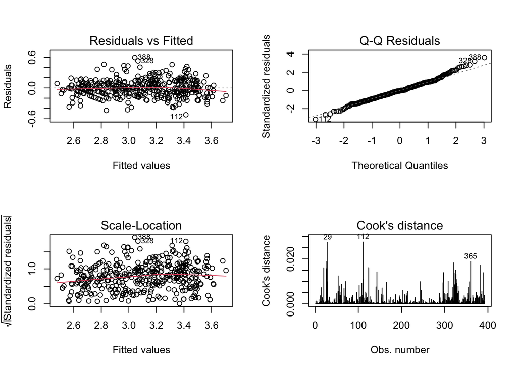

```r
# Diagnóstico del modelo transformado: gráficos de residuos
par(mfrow=c(2,2))
plot(modelo_log, which = 1:4)
```

```r
par(mfrow=c(1,1))
```

### Regresión Lineal Múltiple y Variables Dummy

Para capturar mejor la complejidad de los datos, ajusté un modelo de regresión lineal múltiple incluyendo variables como la potencia y la aceleración. También utilicé variables dummy para representar variables categóricas como el origen del automóvil.

```r
# Regresión Lineal Múltiple
modelo_multiple <- lm(mpg ~ weight + horsepower + acceleration, data = df)
resumen_modelo_multi <- summary(modelo_multiple)

# Imprimir resumen del modelo
print(resumen_modelo_multi)
```

```
##
## Call:
## lm(formula = mpg ~ weight + horsepower + acceleration, data = df)
##
## Residuals:
##     Min      1Q  Median      3Q     Max
## -11.079  -2.736  -0.331   2.170  16.262
##
## Coefficients:
##                Estimate Std. Error t value Pr(>|t|)
## (Intercept)  45.6782929  2.4085431  18.965  < 2e-16 ***
## weight       -0.0057894  0.0005776 -10.024  < 2e-16 ***
## horsepower   -0.0474956  0.0159891  -2.970  0.00316 **
## acceleration -0.0020657  0.1233378  -0.017  0.98665
## ---
## Signif. codes:  0 '***' 0.001 '**' 0.01 '*' 0.05 '.' 0.1 ' ' 1
##
## Residual standard error: 4.246 on 388 degrees of freedom
## Multiple R-squared:  0.7064, Adjusted R-squared:  0.7041
## F-statistic: 311.1 on 3 and 388 DF,  p-value: < 2.2e-16
```

```r
# Extraer y imprimir el R cuadrado
r_squared_multi <- resumen_modelo_multi$r.squared
r_squared_ajustado_multi <- resumen_modelo_multi$adj.r.squared

cat("R cuadrado: ", r_squared_multi, "\n")
```

```
## R cuadrado:  0.7063755
```

```r
cat("R cuadrado ajustado: ", r_squared_ajustado_multi, "\n")
```

```
## R cuadrado ajustado:  0.7041052
```

```r
# Evaluar multicolinealidad
if (!require(car)) install.packages("car")
library(car)
vif(modelo_multiple)
```

```
##       weight   horsepower acceleration
##     5.220633     8.216084     2.511571
```

```r
# Ajustar el modelo eliminando una variable si hay alta multicolinealidad
modelo_sin_multicolinealidad <- lm(mpg ~ weight + horsepower, data = df)
summary(modelo_sin_multicolinealidad)
```

```
##
## Call:
## lm(formula = mpg ~ weight + horsepower, data = df)
##
## Residuals:
##      Min       1Q   Median       3Q      Max
## -11.0762  -2.7340  -0.3312   2.1752  16.2601
##
## Coefficients:
##               Estimate Std. Error t value Pr(>|t|)
## (Intercept) 45.6402108  0.7931958  57.540  < 2e-16 ***
## weight      -0.0057942  0.0005023 -11.535  < 2e-16 ***
## horsepower  -0.0473029  0.0110851  -4.267 2.49e-05 ***
## ---
## Signif. codes:  0 '***' 0.001 '**' 0.01 '*' 0.05 '.' 0.1 ' ' 1
##
## Residual standard error: 4.24 on 389 degrees of freedom
## Multiple R-squared:  0.7064, Adjusted R-squared:  0.7049
## F-statistic: 467.9 on 2 and 389 DF,  p-value: < 2.2e-16
```

### Regularización

Para manejar posibles problemas de multicolinealidad y mejorar la precisión del modelo, implementé técnicas de regularización como Ridge y Lasso.

```r
# Regularización
if (!require(glmnet)) install.packages("glmnet")
library(glmnet)

# Preparar los datos para glmnet
x <- model.matrix(mpg ~ weight + horsepower + acceleration, data = df)[,-1]
y <- df$mpg

# Ajustar el modelo Ridge
modelo_ridge <- cv.glmnet(x, y, alpha = 0)

# Ajustar el modelo Lasso
modelo_lasso <- cv.glmnet(x, y, alpha = 1)

# Imprimir los coeficientes del modelo Ridge y Lasso
print(coef(modelo_ridge, s = "lambda.min"))
```

```
## 4 x 1 sparse Matrix of class "dgCMatrix"
##                        s1
## (Intercept)  44.319876933
## weight       -0.004926504
## horsepower   -0.059054800
## acceleration -0.002281626
```

```r
print(coef(modelo_lasso, s = "lambda.min"))
```

```
## 4 x 1 sparse Matrix of class "dgCMatrix"
##                        s1
## (Intercept)  45.167164251
## weight       -0.005708548
## horsepower   -0.045214803
## acceleration  .
```

```r
# Variables Dummy
df$origin <- as.factor(df$origin)
dummies <- model.matrix(~ origin - 1, data = df)
df <- cbind(df, dummies)

# Ajustar el modelo con las variables dummy incluidas
modelo_dummy <- lm(mpg ~ weight + horsepower + acceleration + origin2 + origin3, data = df)
resumen_modelo_dummy <- summary(modelo_dummy)

# Imprimir resumen del modelo
print(resumen_modelo_dummy)
```

```
##
## Call:
## lm(formula = mpg ~ weight + horsepower + acceleration + origin2 +
##     origin3, data = df)
##
## Residuals:
##      Min       1Q   Median       3Q      Max
## -12.4230  -2.9300  -0.3662   2.2318  14.8352
##
## Coefficients:
##                Estimate Std. Error t value Pr(>|t|)
## (Intercept)  43.2914124  2.4351853  17.777  < 2e-16 ***
## weight       -0.0047672  0.0006219  -7.666 1.46e-13 ***
## horsepower   -0.0564319  0.0158182  -3.568 0.000406 ***
## acceleration -0.0308513  0.1214768  -0.254 0.799655
## origin2       0.9765649  0.6439097   1.517 0.130182
## origin3       2.7524440  0.6537309   4.210 3.18e-05 ***
## ---
## Signif. codes:  0 '***' 0.001 '**' 0.01 '*' 0.05 '.' 0.1 ' ' 1
##
## Residual standard error: 4.162 on 386 degrees of freedom
## Multiple R-squared:  0.7193, Adjusted R-squared:  0.7157
## F-statistic: 197.9 on 5 and 386 DF,  p-value: < 2.2e-16
```

```r
# Evaluación de multicolinealidad
vif(modelo_dummy)
```

```
##       weight   horsepower acceleration      origin2      origin3
##     6.299228     8.369036     2.535632     1.345488     1.556487
```

```r
# Evaluación de bondad de ajuste
r_squared_dummy <- resumen_modelo_dummy$r.squared
r_squared_ajustado_dummy <- resumen_modelo_dummy$adj.r.squared

cat("R cuadrado del modelo con dummies: ", r_squared_dummy, "\n")
```

```
## R cuadrado del modelo con dummies:  0.7193262
```

```r
cat("R cuadrado ajustado del modelo con dummies: ", r_squared_ajustado_dummy, "\n")
```

```
## R cuadrado ajustado del modelo con dummies:  0.7156906
```

## Resultados: Evaluación y Comparativa de Modelos

### Comparativa de Modelos

```r
# Modelo Libre: Selección de variables
df$origin <- as.factor(df$origin)
dummies <- model.matrix(~ origin - 1, data = df)
df <- cbind(df, dummies)

modelo_combinado <- lm(mpg ~ weight + horsepower + acceleration + cylinders + displacement + origin2 + origin3, data = df)
resumen_modelo_combinado <- summary(modelo_combinado)

# Imprimir resumen del modelo
print(resumen_modelo_combinado)
```

```
##
## Call:
## lm(formula = mpg ~ weight + horsepower + acceleration + cylinders +
##     displacement + origin2 + origin3, data = df)
##
## Residuals:
##      Min       1Q   Median       3Q      Max
## -12.6303  -2.8009  -0.2871   2.0945  14.8931
##
## Coefficients:
##                Estimate Std. Error t value Pr(>|t|)
## (Intercept)  44.7687911  2.6398457  16.959  < 2e-16 ***
## weight       -0.0048119  0.0008089  -5.948  6.1e-09 ***
## horsepower   -0.0613339  0.0168679  -3.636 0.000314 ***
## acceleration -0.0319841  0.1232529  -0.259 0.795389
## cylinders    -0.5661876  0.4042069  -1.401 0.162100
## displacement  0.0114270  0.0095737   1.194 0.233376
## origin2       1.1255451  0.7015566   1.604 0.109458
## origin3       2.9325397  0.6955675   4.216  3.1e-05 ***
## ---
## Signif. codes:  0 '***' 0.001 '**' 0.01 '*' 0.05 '.' 0.1 ' ' 1
##
## Residual standard error: 4.161 on 384 degrees of freedom
## Multiple R-squared:  0.7209, Adjusted R-squared:  0.7158
## F-statistic: 141.7 on 7 and 384 DF,  p-value: < 2.2e-16
```

```r
# Evaluación de bondad de ajuste
r_squared_combinado <- resumen_modelo_combinado$r.squared
r_squared_ajustado_combinado <- resumen_modelo_combinado$adj.r.squared

cat("R cuadrado del modelo combinado: ", r_squared_combinado, "\n")
```

```
## R cuadrado del modelo combinado:  0.7208517
```

```r
cat("R cuadrado ajustado del modelo combinado: ", r_squared_ajustado_combinado, "\n")
```

```
## R cuadrado ajustado del modelo combinado:  0.7157631
```

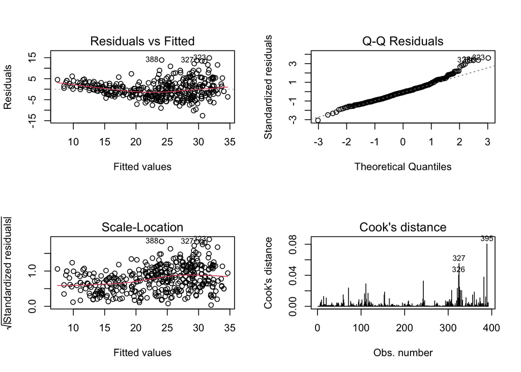

```r
# Evaluación del modelo: gráficos de residuos
par(mfrow=c(2,2))
plot(modelo_combinado, which = 1:4)
```

```r
par(mfrow=c(1,1))

# Evaluación de multicolinealidad
vif(modelo_combinado)
```

```
##       weight   horsepower acceleration    cylinders displacement      origin2
##    10.661322     9.519093     2.610987    10.735068    22.663931     1.597593
##      origin3
##     1.762531
```

## Conclusiones

### Reflexión Final

Este ejercicio no solo reforzó mi comprensión de la regresión lineal, sino que también destacó la importancia de un enfoque meticuloso en el análisis de datos. Compartir estos aprendizajes puede ayudar a otros entusiastas a evitar errores comunes y a mejorar la calidad de sus análisis.

Espero que esta experiencia y los pasos detallados aquí sean útiles para aquellos que están empezando en el análisis de datos y la regresión lineal. ¡Feliz análisis de datos!